# Analiza frekvenc z diskretno Fourierjevo transformacijo

```python
import numpy as np
import matplotlib.pyplot as plt
import soundfile as sf
from scipy import signal
```

## Konstante

Najvišja frekvenca je določena, saj pri začetnem zagonu z najvišjo frekvenco 5000 Hz podatki nad 1500 Hz niso bili pomembni pri nobenem zvoku. Spodaj je graf z najvišjo frekvenco.

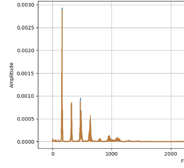

```python
from IPython.display import Image
Image(filename='0_to_5_kHz_result.png')
```

```python
SamplingRate = 44100
MaxFrequency = 1500
FrequencyBins = int(MaxFrequency * 3 / SamplingRate * SamplingRate)
```

## Funkcije

```python
def LoadAudio(FilePath):
    AudioData, SampleRate = sf.read(FilePath)
    if SampleRate != SamplingRate:
        raise ValueError("Sampling rate mismatch")
    return AudioData[:3*SamplingRate]

def ComputeRealScalarProduct(Signal, Frequency, Length):
    TimeVector = np.arange(Length) / SamplingRate
    CosineBasis = np.cos(2 * np.pi * Frequency * TimeVector)
    SineBasis = np.sin(2 * np.pi * Frequency * TimeVector)
    CosineAmplitude = np.dot(Signal, CosineBasis) / Length
    SineAmplitude = np.dot(Signal, SineBasis) / Length
    return np.sqrt(CosineAmplitude**2 + SineAmplitude**2)

def ComputeComplexScalarProduct(Signal, Frequency, Length):
    TimeVector = np.arange(Length) / SamplingRate
    ComplexBasis = np.exp(-2j * np.pi * Frequency * TimeVector)
    ComplexAmplitude = np.dot(Signal, ComplexBasis) / Length
    return np.abs(ComplexAmplitude)

def CustomDFT(Signal, IsComplex=True):
    Frequencies = np.linspace(0, MaxFrequency, FrequencyBins)
    Spectrum = np.zeros(FrequencyBins)
    for Index, Freq in enumerate(Frequencies):
        if IsComplex:
            Spectrum[Index] = ComputeComplexScalarProduct(Signal, Freq, len(Signal))
        else:
            Spectrum[Index] = ComputeRealScalarProduct(Signal, Freq, len(Signal))
    return Frequencies, Spectrum

def ComputeFFT(Signal):
    FFTResult = np.fft.fft(Signal)
    Frequencies = np.fft.fftfreq(len(Signal), 1/SamplingRate)
    PositiveMask = (Frequencies >= 0) & (Frequencies <= MaxFrequency)
    return Frequencies[PositiveMask], np.abs(FFTResult[PositiveMask]) / len(Signal)

def PlotSpectrum(RealFrequencies, RealSpectrum, ComplexFrequencies, ComplexSpectrum, Title, FFTFrequencies=None, FFTSpectrum=None):
    fig, (ax1, ax2) = plt.subplots(1, 2, figsize=(15, 5), sharey=True)

    ax1.plot(RealFrequencies, RealSpectrum, label="Real DFT", color='blue')
    if FFTFrequencies is not None and FFTSpectrum is not None:
        ax1.plot(FFTFrequencies, FFTSpectrum, label="FFT", alpha=0.7, color='orange')
    ax1.set_title(f"{Title} - Real DFT")
    ax1.set_xlabel("Frequency (Hz)")
    ax1.set_ylabel("Amplitude")
    ax1.grid(True)
    ax1.legend()

    ax2.plot(ComplexFrequencies, ComplexSpectrum, label="Complex DFT", color='green')
    if FFTFrequencies is not None and FFTSpectrum is not None:
        ax2.plot(FFTFrequencies, FFTSpectrum, label="FFT", alpha=0.7, color='orange')
    ax2.set_title(f"{Title} - Complex DFT")
    ax2.set_xlabel("Frequency (Hz)")
    ax2.grid(True)
    ax2.legend()

    plt.tight_layout()
    plt.show()

def ComputeEnergyByFrequency(Frequencies, Spectrum):
    Energy = np.power(Spectrum, 2)
    TotalEnergy = np.sum(Energy)
    SignificantFrequencies = Frequencies[Energy > 0.01 * TotalEnergy]
    SignificantAmplitudes = Spectrum[Energy > 0.01 * TotalEnergy]
    return SignificantFrequencies, SignificantAmplitudes

def CompareDFTSpectra(RealFrequencies, RealSpectrum, ComplexFrequencies, ComplexSpectrum, Title="DFT Comparison"):
    if not np.array_equal(RealFrequencies, ComplexFrequencies):
        raise ValueError("Real and Complex DFT frequencies must match")

    AbsDifference = np.abs(RealSpectrum - ComplexSpectrum)

    RelativeDifference = np.zeros_like(AbsDifference)
    mask = ComplexSpectrum > 1e-10
    RelativeDifference[mask] = AbsDifference[mask] / ComplexSpectrum[mask]

    print(f"{Title} - statistika razlik:")
    print(f"Povprečna absolutna razlika (realno - kompleksno): {np.mean(AbsDifference):.4f}")
    print(f"Največja absolutna razlika (realno - kompleksno): {np.max(AbsDifference):.4f}")
    print(f"Povprečna relativna razlika (realno - kompleksno): {np.mean(RelativeDifference[mask]):.4f}")
```

## Analiza samoglasnikov

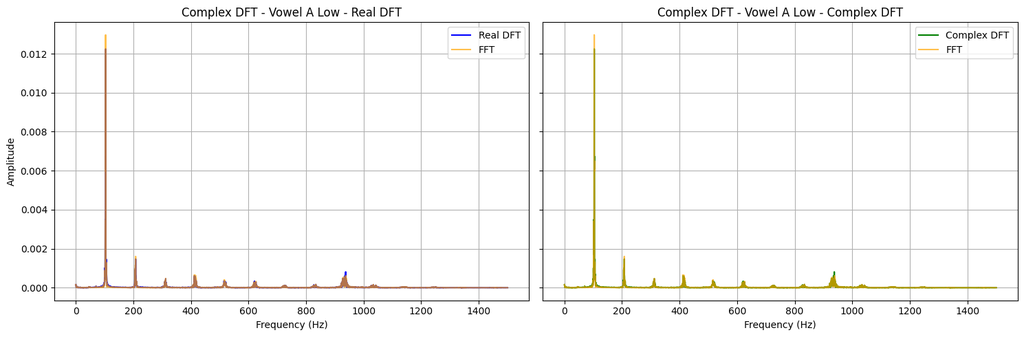

```
Vowel A Low - statistika razlik:
Povprečna absolutna razlika (realno - kompleksno): 0.0000
Največja absolutna razlika (realno - kompleksno): 0.0000
Povprečna relativna razlika (realno - kompleksno): 0.0000
Pomembne frekvence samoglasnika A Low nizek (Hz): [102.35607913 102.68948655 103.3563014  103.68970882 104.02311625
 104.35652367]
Ustrezne amplitude: [0.00349908 0.00337456 0.00909343 0.01224297 0.00606754 0.00673749]
```

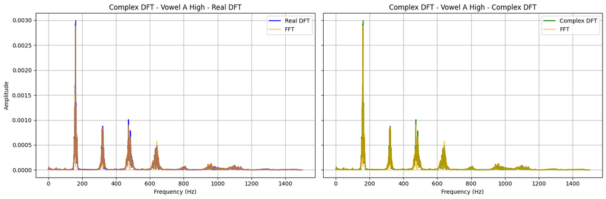

```
Vowel A High - statistika razlik:
Povprečna absolutna razlika (realno - kompleksno): 0.0000
Največja absolutna razlika (realno - kompleksno): 0.0000
Povprečna relativna razlika (realno - kompleksno): 0.0000
Pomembne frekvence samoglasnika A High nizek (Hz): [156.03467437 157.03489664 158.03511892 158.70193376 159.03534119
 159.36874861 160.03556346 160.70237831 161.03578573 161.36919315
 161.70260058 162.036008   162.36941543 163.70304512 164.36985997
 473.4385419 ]
Ustrezne amplitude: [0.00124284 0.001388   0.00133179 0.00169953 0.00150024 0.00202481
 0.00292927 0.00207267 0.00126011 0.00211151 0.00299411 0.00158908
 0.00142956 0.00095736 0.00134292 0.00100751]
```

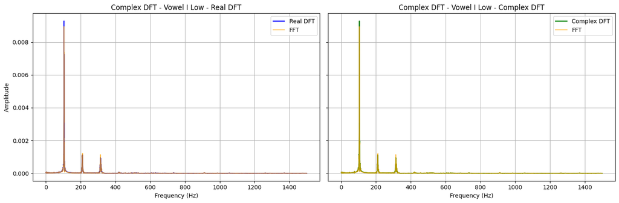

```
Vowel I Low - statistika razlik:
Povprečna absolutna razlika (realno - kompleksno): 0.0000
Največja absolutna razlika (realno - kompleksno): 0.0000
Povprečna relativna razlika (realno - kompleksno): 0.0000
Pomembne frekvence samoglasnika I Low nizek (Hz): [103.3563014  103.68970882 104.02311625 104.35652367 104.6899311
 105.02333852 105.35674594 105.69015337 106.02356079 106.35696822
 106.69037564]
Ustrezne amplitude: [0.00177232 0.00311775 0.00368427 0.00928308 0.00400278 0.00215231
 0.00726485 0.00680923 0.0021886  0.00178119 0.0019689 ]
```

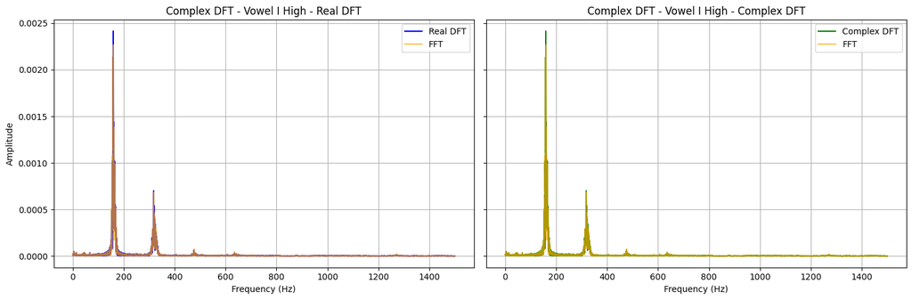

```
Vowel I High - statistika razlik:
Povprečna absolutna razlika (realno - kompleksno): 0.0000
Največja absolutna razlika (realno - kompleksno): 0.0000
Povprečna relativna razlika (realno - kompleksno): 0.0000
Pomembne frekvence samoglasnika I High nizek (Hz): [155.70126695 156.03467437 156.3680818  157.03489664 157.70171149
 158.03511892 158.36852634 158.70193376 159.03534119 159.36874861
 159.70215603 160.03556346 161.03578573 161.70260058 162.036008
 163.03623027 163.3696377  163.70304512 164.36985997 164.70326739
 317.40386753 317.73727495]
Ustrezne amplitude: [0.00101785 0.00069675 0.00098038 0.0007167  0.00106035 0.00125601
 0.00213508 0.00111136 0.00241521 0.00180598 0.00160523 0.00140411
 0.00143886 0.00098935 0.0010373  0.0006626  0.00081111 0.00081379
 0.00075653 0.00101759 0.00066179 0.00070187]
```

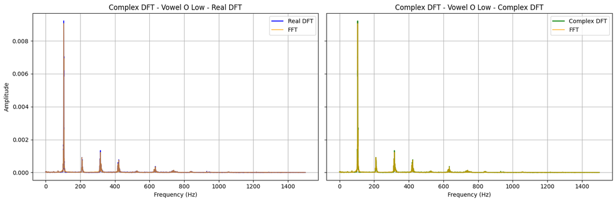

```
Vowel O Low - statistika razlik:
Povprečna absolutna razlika (realno - kompleksno): 0.0000
Največja absolutna razlika (realno - kompleksno): 0.0000
Povprečna relativna razlika (realno - kompleksno): 0.0000
Pomembne frekvence samoglasnika O Low nizek (Hz): [104.35652367 104.6899311  105.02333852 105.35674594 105.69015337
 106.02356079 106.69037564]
Ustrezne amplitude: [0.00354761 0.00921587 0.008319   0.00584088 0.00705258 0.00504781
 0.00272293]
```

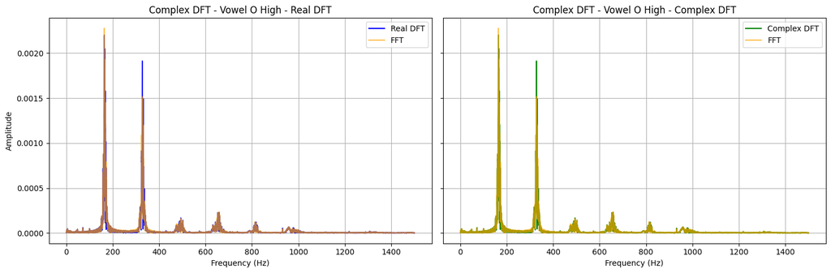

```
Vowel O High - statistika razlik:
Povprečna absolutna razlika (realno - kompleksno): 0.0000
Največja absolutna razlika (realno - kompleksno): 0.0000
Povprečna relativna razlika (realno - kompleksno): 0.0000
Pomembne frekvence samoglasnika O High nizek (Hz): [160.70237831 163.03623027 163.3696377  163.70304512 164.03645255
 164.36985997 164.70326739 165.03667482 165.37008224 166.37030451
 167.03711936 167.37052678 167.70393421 168.37074906 169.0375639
 169.70437875 324.40542343 327.07268282 327.40609024 327.73949767
 328.07290509 329.07312736 329.40653479 329.73994221 331.40697933]
Ustrezne amplitude: [0.00087707 0.00127702 0.00140779 0.00217989 0.00220034 0.00167277
 0.00151372 0.00205053 0.00127787 0.00183846 0.00114685 0.0011923
 0.00157951 0.00106601 0.00120665 0.00101862 0.00091355 0.00089604
 0.00122704 0.0019118  0.00086766 0.00124581 0.00133612 0.00131356
 0.00149192]
```

```python
VowelFiles = {
    "A Low": "ALow.wav",
    "A High": "AHigh.wav",
    "I Low": "ILow.wav",
    "I High": "IHigh.wav",
    "O Low": "OLow.wav",
    "O High": "OHigh.wav"
}

for VowelKey, FilePath in VowelFiles.items():
    Signal = LoadAudio("./sounds/" + FilePath)

    FFTFrequencies, FFTSpectrum = ComputeFFT(Signal)
    RealFrequencies, RealSpectrum = CustomDFT(Signal, IsComplex=False)
    ComplexFrequencies, ComplexSpectrum = CustomDFT(Signal, IsComplex=True)

    PlotSpectrum(RealFrequencies, RealSpectrum, ComplexFrequencies, ComplexSpectrum, f"Complex DFT - Vowel {VowelKey}", FFTFrequencies, FFTSpectrum)

    CompareDFTSpectra(RealFrequencies, RealSpectrum, ComplexFrequencies, ComplexSpectrum, Title=f"Vowel {VowelKey}")

    SignificantFrequencies, SignificantAmplitudes = ComputeEnergyByFrequency(ComplexFrequencies, ComplexSpectrum)
    print(f"Pomembne frekvence samoglasnika {VowelKey} nizek (Hz):", SignificantFrequencies)
    print(f"Ustrezne amplitude:", SignificantAmplitudes)
```

## Answers To Questions

### 2. Ali lahko frekvenčno sliko signala nedvoumno določimo preko skalarnega produkta med posnetim signalom in izbrano kompleksno sinusoido? Kako na to vpliva dolžina opazovanega intervala signala? Zakaj?

Da, frekvenčni spekter je mogoče enolično določiti z uporabo skalarnih produktov s kompleksnim sinusoidom. Kompleksni sinusoidi zajamejo tako amplitudo kot fazo. Dolžina intervala opazovanja vpliva na frekvenčno ločljivost: krajši intervali povzročijo širše vrhove, medtem ko daljši intervali izboljšajo ločljivost z oženjem vrhov. To je zato, ker je frekvenčna ločljivost obratno sorazmerna z dolžino signala (`Δf = 1/T`). Grafi kompleksne DFT se zelo ujemajo z FFT, kar potrjuje njihovo natančnost.

### 3. Katere vse frekvence so prisotne v izgovorjavi samoglasnikov »a«, »i« in »o« (osredotočite se na frekvence, ki predstavljajo vsaj 1 % celotne energije signala)?

Pomembne frekvence (ki prispevajo vsaj 1 % energije signala) so izpisane zgoraj za vsak samoglasnik.

### 4. Kako so frekvence, ki so prisotne v izgovorjavi samoglasnikov »a«, »i« in »o« odvisne od višine tona izgovorjave?

Višja višina poveča osnovno frekvenco in premakne harmonike na višje frekvence.